# Student clustering based on the regularity of study indicators

First, read in the computed indicators:

- number of active days per week
- SD and entropy of active days per week
- median time gap between consecutive active days

```r
## load active days per week, SD and entropy
weekly.counts <- read.csv("Intermediate_results/regularity_of_study/weekly_counts_of_daily_logins_w2-13.csv")
weekly.counts <- weekly.counts %>%
  select(user_id, W2_cnt:W13_cnt, weekly_cnt_sd, weekly_entropy)
#str(weekly.counts)
## load also data about time gaps between consecutive active days
time.gaps <- read.csv("Intermediate_results/regularity_of_study/gaps_between_consecutive_logins_w2-13.csv")
## mean and SD are not very meaningful since only 2% of students have normally distributed time gaps
time.gaps <- time.gaps %>% select(user_id, median_gap)
## merge the indictors
counts <- merge(x = weekly.counts, y = time.gaps, by = 'user_id', all = T)
str(counts)
```

```
'data.frame':   486 obs. of  16 variables:
 $ user_id       : num  679 680 681 682 683 688 689 691 693 694 ...
 $ W2_cnt        : int  5 5 4 2 2 1 2 5 3 2 ...
 $ W3_cnt        : int  4 5 4 2 2 2 4 5 3 3 ...
 $ W4_cnt        : int  5 5 2 1 2 0 1 2 3 4 ...
 $ W5_cnt        : int  5 5 2 1 1 1 3 6 3 3 ...
 $ W6_cnt        : int  5 5 2 5 5 5 3 4 5 3 ...
 $ W7_cnt        : int  3 3 3 2 5 1 2 3 2 5 ...
 $ W8_cnt        : int  5 2 4 3 5 1 0 4 3 3 ...
 $ W9_cnt        : int  5 4 3 1 1 1 0 2 2 2 ...
 $ W10_cnt       : int  2 5 3 3 3 1 1 4 2 3 ...
 $ W11_cnt       : int  4 3 2 2 2 1 2 4 2 2 ...
 $ W12_cnt       : int  5 6 3 2 2 2 2 2 3 4 ...
 $ W13_cnt       : int  5 3 1 2 0 0 0 1 2 1 ...
 $ weekly_cnt_sd : num  0.996 1.215 0.965 1.115 1.679 ...
 $ weekly_entropy: num  -0.0835 -0.0856 -0.0884 -0.0976 -0.1103 ...
 $ median_gap    : num  0 0 1 0.5 1.5 2.5 2 1 0 0 ...
```

Read in students’ exam scores:

```r
exam.scores <- read.csv(file = "Intermediate_results/exam_scores_with_student_ids.csv")
# remove email data
exam.scores <- exam.scores %>% select(-2)
str(exam.scores)
```

```
'data.frame':   491 obs. of  3 variables:
 $ USER_ID  : int  NA 1446 961 866 937 734 1077 953 852 932 ...
 $ SC_MT_TOT: int  6 11 13 15 17 12 13 15 8 16 ...
 $ SC_FE_TOT: int  0 15 15 24 27 11 11 35 12 33 ...
```

Merge indicators with exam scores

```r
counts_and_scores <- merge(x = counts, y = exam.scores,
                           by.x = 'user_id', by.y = 'USER_ID',
                           all.x = T, all.y = F)
#summary(counts_and_scores)
counts_and_scores <- counts_and_scores %>% filter( is.na(SC_FE_TOT)==FALSE )
```

Check for normality of variables

```r
apply(counts_and_scores[,-1], 2, shapiro.test)
```

Except for tot_cnt, no other variable is normally distributed -> use Spearman corr.

Use the [ggcorr](https://briatte.github.io/ggcorr/) f. for computing and plotting the correlations among variables

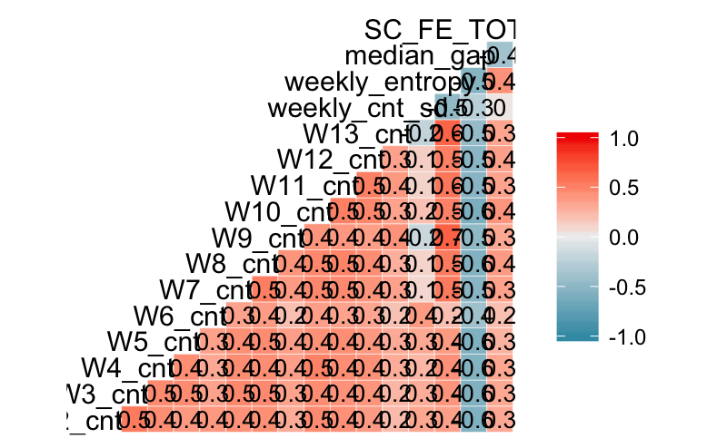

```r
source("https://raw.githubusercontent.com/briatte/ggcorr/master/ggcorr.R")
ggcorr(counts_and_scores[,-c(1,17)], method = c("complete","spearman"),
       #      geom = "circle", min_size = 0, max_size = 15,
       label = TRUE, label_size = 3.5,
       hjust = 0.85, size = 4, layout.exp = 1)
```

Relatively low correlations between the indicators and the final exam score (SC_FE_TOT).

Check for zero or near-zero variance predictors

```r
## using the nearZeroVar f. from caret:
## https://topepo.github.io/caret/pre-processing.html#zero--and-near-zero-variance-predictors
nzv <- nearZeroVar(counts_and_scores[,-1], saveMetrics= TRUE)
nzv
```

|  | freqRatio | percentUnique | zeroVar | nzv |
| --- | --- | --- | --- | --- |
| W2_cnt | 1.189189 | 1.677149 | FALSE | FALSE |
| W3_cnt | 1.050000 | 1.677149 | FALSE | FALSE |
| W4_cnt | 1.016529 | 1.677149 | FALSE | FALSE |
| W5_cnt | 1.288462 | 1.677149 | FALSE | FALSE |
| W6_cnt | 1.472222 | 1.677149 | FALSE | FALSE |
| W7_cnt | 1.711538 | 1.677149 | FALSE | FALSE |
| W8_cnt | 1.400000 | 1.677149 | FALSE | FALSE |
| W9_cnt | 1.015038 | 1.467505 | FALSE | FALSE |
| W10_cnt | 1.000000 | 1.677149 | FALSE | FALSE |
| W11_cnt | 1.112000 | 1.677149 | FALSE | FALSE |

[output cut: 7 more lines]

None has near-zero variance.

Check for outliers:

```r
outliers <- apply(counts_and_scores[,-c(1,17,18)], 2, function(x) length(boxplot.stats(x)$out))
outliers <- outliers[outliers>0]
sort(outliers, decreasing = T)
```

```
        W3_cnt weekly_entropy     median_gap        W13_cnt  weekly_cnt_sd
            74             33             29              6              6
```

Look more closely at variables with large number of outliers

```r
table(counts_and_scores$W3_cnt)
sort(boxplot.stats(counts_and_scores$W3_cnt)$out)
summary(counts_and_scores$weekly_entropy)
sort(boxplot.stats(counts_and_scores$weekly_entropy)$out)
summary(counts_and_scores$median_gap)
sort(boxplot.stats(counts_and_scores$median_gap)$out)
```

Use Winsorizing to replace the extreme values with less extreme ones

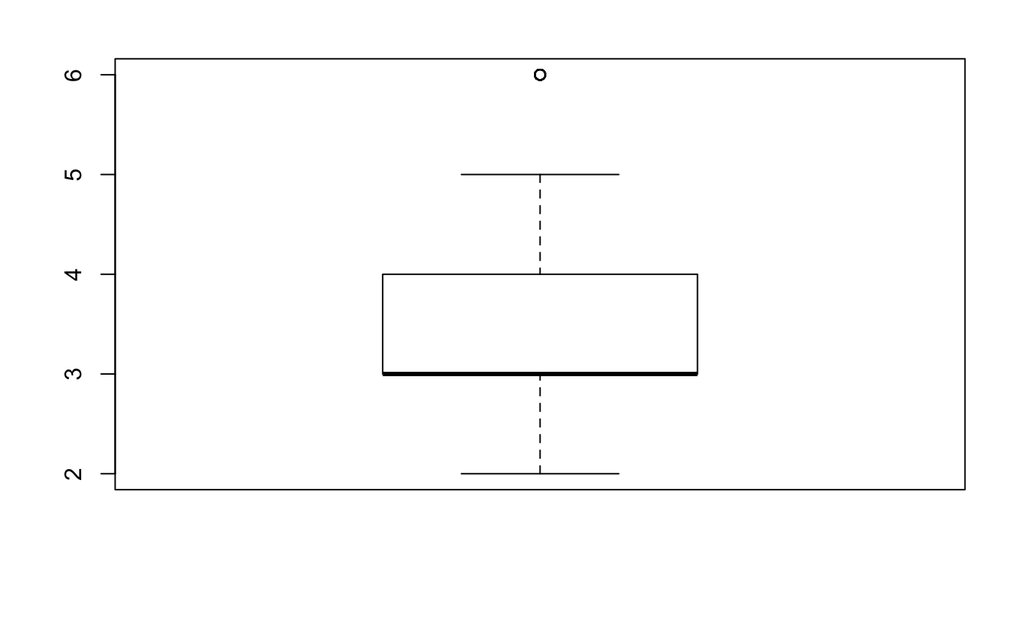

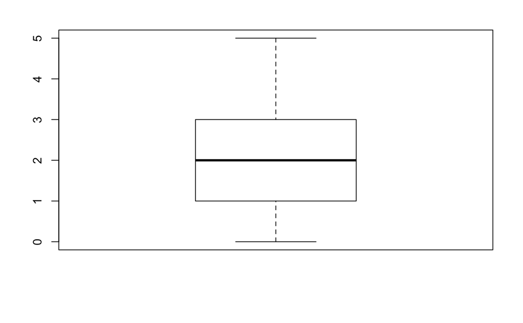

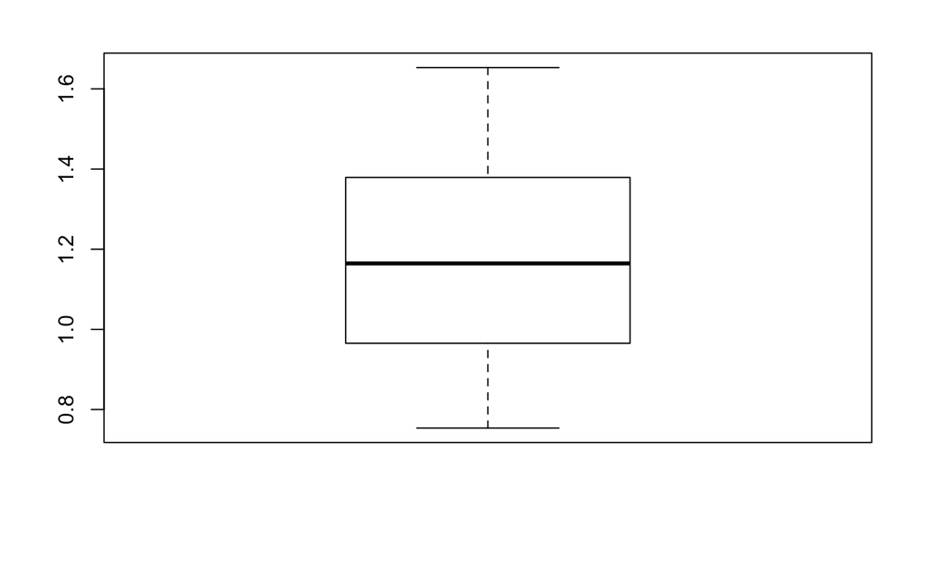

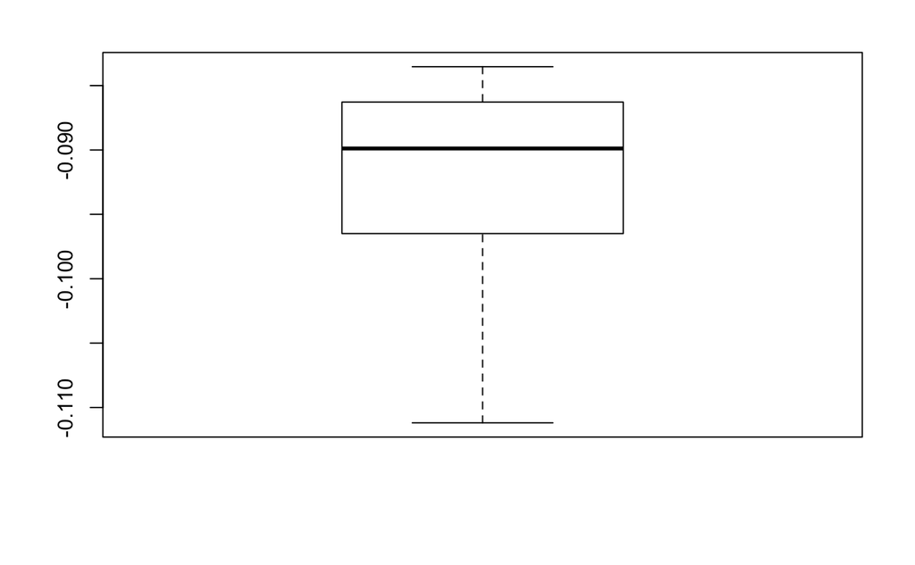

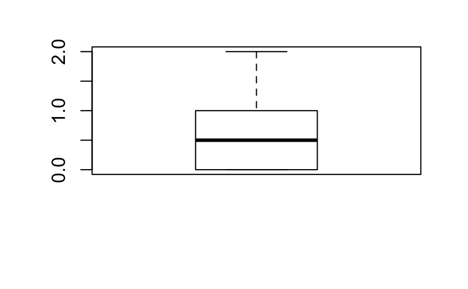

```r
vars_to_winsorize <- counts_and_scores %>%
  select(one_of(names(outliers)))
winsorized_data_v1 <- data.frame(apply(vars_to_winsorize, 2, winsor1, fraction=0.07))
```

```r
apply(winsorized_data_v1, 2, function(x) length(boxplot.stats(x)$out))
summary(winsorized_data_v1)
#winsorized_data_v2 <- data.frame(apply(vars_to_winsorize, 2, winsor2))
#apply(winsorized_data_v2, 2, function(x) length(boxplot.stats(x)$out))
#summary(winsorized_data_v2)
```

Except for W3 counts, all other outliers are resolved.

Merge winsorized variables with the other variables

```r
features <- counts_and_scores %>%
  select(-one_of(names(outliers))) %>%
  select(-c(SC_MT_TOT, SC_FE_TOT)) %>%
  cbind(winsorized_data_v1)
# change the order of variables, to make it easier for later interpretation
features <- features %>% select(1,2,12,3:11,13:16)
str(features)
```

```
'data.frame':   477 obs. of  16 variables:
 $ user_id       : num  679 680 681 682 683 688 689 691 693 694 ...
 $ W2_cnt        : int  5 5 4 2 2 1 2 5 3 2 ...
 $ W3_cnt        : num  4 5 4 2 2 2 4 5 3 3 ...
 $ W4_cnt        : int  5 5 2 1 2 0 1 2 3 4 ...
 $ W5_cnt        : int  5 5 2 1 1 1 3 6 3 3 ...
 $ W6_cnt        : int  5 5 2 5 5 5 3 4 5 3 ...
 $ W7_cnt        : int  3 3 3 2 5 1 2 3 2 5 ...
 $ W8_cnt        : int  5 2 4 3 5 1 0 4 3 3 ...
 $ W9_cnt        : int  5 4 3 1 1 1 0 2 2 2 ...
 $ W10_cnt       : int  2 5 3 3 3 1 1 4 2 3 ...
 $ W11_cnt       : int  4 3 2 2 2 1 2 4 2 2 ...
 $ W12_cnt       : int  5 6 3 2 2 2 2 2 3 4 ...
 $ W13_cnt       : num  5 3 1 2 0 0 0 1 2 1 ...
 $ weekly_cnt_sd : num  0.996 1.215 0.965 1.115 1.653 ...
 $ weekly_entropy: num  -0.0835 -0.0856 -0.0884 -0.0976 -0.1103 ...
 $ median_gap    : num  0 0 1 0.5 1.5 2 2 1 0 0 ...
```

Remove weekly_cnt_sd from the feature set since it has zero correlation with the final exam score.

```r
features <- features %>% select(-weekly_cnt_sd)
```

Scale feature values; since outliers have been removed, normalization can be used

```r
summary(features[,-1])
f.scaled <- data.frame(apply(features[,-1], 2, normalize.feature ))
summary(f.scaled)
f.scaled <- data.frame(cbind(user_id=features$user_id, f.scaled))
```

# Do the clustering

Hierarchical clustering:

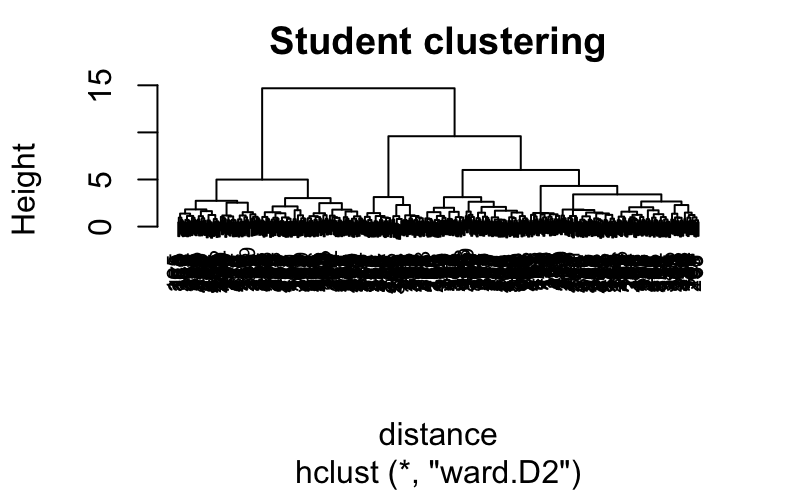

```r
hc <- do.hclustering(f.scaled[,-1], 'ward.D2')
```

3 or 4 seem to be the best options

```r
## examine various cluster models
clusters <- sapply(3:8, function(ncl) table(cutree(hc, k = ncl)))
names(clusters) <- c(3:8)
clusters
```

```
$`3`

  1   2   3
170 251  56

$`4`

  1   2   3   4
170 155  56  96

$`5`

  1   2   3   4   5
 94 155  56  96  76

$`6`

  1   2   3   4   5   6
 94 127  28  56  96  76

$`7`

 1  2  3  4  5  6  7
94 52 75 28 56 96 76

$`8`

 1  2  3  4  5  6  7  8
94 52 75 28 30 96 26 76
```

Try also k-medoids

```r
med.cl <- do.kmedoids.clustering(f.scaled, k.min = 3, k.max = 7)
```

```
[1] 3

  1   2   3
189 210  78
Silhouette of 477 units in 3 clusters from pam(x = sdata, k = k, diss = diss, metric = "euclidean") :
 Cluster sizes and average silhouette widths:
      189       210        78
0.6239699 0.6047833 0.8823593
Individual silhouette widths:
    Min.  1st Qu.   Median     Mean  3rd Qu.     Max.
-0.02261  0.59120  0.71940  0.65780  0.75860  0.91450
```

3 clusters according to K-medoids

## Examine cluster models obtained through HC

Examine the 3 cluster model:

```r
cl3.stats <- summary.stats(features[,-1],
                           clusters = stud.clust$cl3, cl.number = 3)
kable(cl3.stats)
```

| attributes | Median; (Q1, Q3) | Median; (Q1, Q3) | Median; (Q1, Q3) |
| --- | --- | --- | --- |
| cluster | 1 | 2 | 3 |
| freq | 170 | 251 | 56 |
| W2_cnt | 5; (4, 5) | 3; (3, 4) | 2; (1, 2) |
| W3_cnt | 5; (4, 6) | 3; (2, 4) | 2; (2, 2) |
| W4_cnt | 4; (4, 5) | 3; (2, 4) | 2; (1, 2) |
| W5_cnt | 4.5; (4, 5) | 3; (3, 4) | 2; (1, 2.25) |
| W6_cnt | 4; (4, 5) | 4; (3, 4) | 2; (1, 3) |
| W7_cnt | 4; (3, 4) | 3; (2, 3) | 1; (1, 2) |
| W8_cnt | 4; (3, 4) | 3; (2, 3) | 1; (1, 2) |
| W9_cnt | 3; (2, 4) | 2; (1, 3) | 1; (0, 2) |
| W10_cnt | 4; (3, 5) | 3; (2, 4) | 1; (0, 2) |
| W11_cnt | 4; (3, 4) | 2; (2, 3) | 1; (1, 2) |
| W12_cnt | 4; (3, 5) | 3; (2, 3) | 2; (1, 2) |
| W13_cnt | 3; (2, 4) | 2; (1, 2) | 1; (0, 1) |
| weekly_entropy | -0.09; (-0.09, -0.08) | -0.09; (-0.1, -0.09) | -0.1; (-0.11, -0.1) |
| median_gap | 0; (0, 0) | 1; (0, 1) | 2; (2, 2) |

Now, the 4 cluster model

```r
cl4.stats <- summary.stats(features[,-1],
                           clusters = stud.clust$cl4, cl.number = 4)
kable(cl4.stats)
```

| attributes | Median; (Q1, Q3) | Median; (Q1, Q3) | Median; (Q1, Q3) | Median; (Q1, Q3) |
| --- | --- | --- | --- | --- |
| cluster | 1 | 2 | 3 | 4 |
| freq | 170 | 155 | 56 | 96 |
| W2_cnt | 5; (4, 5) | 3; (2, 4) | 2; (1, 2) | 3; (3, 4) |
| W3_cnt | 5; (4, 6) | 3; (2, 4) | 2; (2, 2) | 3; (3, 4) |
| W4_cnt | 4; (4, 5) | 3; (2, 4) | 2; (1, 2) | 4; (3, 5) |
| W5_cnt | 4.5; (4, 5) | 3; (2, 4) | 2; (1, 2.25) | 4; (3, 5) |
| W6_cnt | 4; (4, 5) | 4; (3, 4) | 2; (1, 3) | 4; (3, 4.25) |
| W7_cnt | 4; (3, 4) | 3; (2, 3) | 1; (1, 2) | 3; (3, 4) |
| W8_cnt | 4; (3, 4) | 2; (2, 3) | 1; (1, 2) | 3; (3, 4) |
| W9_cnt | 3; (2, 4) | 2; (1, 3) | 1; (0, 2) | 3; (2, 3) |
| W10_cnt | 4; (3, 5) | 2; (2, 3) | 1; (0, 2) | 3; (2, 4) |
| W11_cnt | 4; (3, 4) | 2; (2, 3) | 1; (1, 2) | 3; (2, 3) |
| W12_cnt | 4; (3, 5) | 2; (1, 3) | 2; (1, 2) | 3; (2, 4) |
| W13_cnt | 3; (2, 4) | 1; (1, 2) | 1; (0, 1) | 2; (2, 3) |
| weekly_entropy | -0.09; (-0.09, -0.08) | -0.09; (-0.1, -0.09) | -0.1; (-0.11, -0.1) | -0.09; (-0.09, -0.09) |
| median_gap | 0; (0, 0) | 1; (1, 1) | 2; (2, 2) | 0; (0, 1) |

## Compare clusters w.r.t. the students’ exam scores

Merge cluster data with exam scores

```r
stud.clust <- merge(x = stud.clust, y = exam.scores,
                    by.x = 'user_id', by.y = 'USER_ID',
                    all.x = T, all.y = F)
summary(stud.clust %>% select(SC_MT_TOT, SC_FE_TOT))
```

```
   SC_MT_TOT       SC_FE_TOT
 Min.   : 0.00   Min.   : 0.00
 1st Qu.:10.00   1st Qu.:12.00
 Median :13.00   Median :18.00
 Mean   :12.89   Mean   :19.43
 3rd Qu.:16.00   3rd Qu.:27.00
 Max.   :20.00   Max.   :40.00
```

### Examine the 4 clusters model

Compute the summary statistics for the students’ exam scores

```r
stud.cl4.stats <- summary.stats(stud.clust %>% select(SC_MT_TOT, SC_FE_TOT), stud.clust$cl4, 4)
kable(x = stud.cl4.stats)
```

| attributes | Median; (Q1, Q3) | Median; (Q1, Q3) | Median; (Q1, Q3) | Median; (Q1, Q3) |
| --- | --- | --- | --- | --- |
| cluster | 1 | 2 | 3 | 4 |
| freq | 170 | 155 | 56 | 96 |
| SC_MT_TOT | 15; (12, 17) | 12; (9, 15) | 10; (7, 12.25) | 13.5; (11, 16.25) |
| SC_FE_TOT | 24; (16, 32) | 15; (11, 22) | 11; (3.75, 17) | 20; (14, 29.25) |

#### Comparison based on **final** exam scores

```r
kruskal.test(stud.clust$SC_FE_TOT ~ stud.clust$cl4)
```

```
    Kruskal-Wallis rank sum test

data:  stud.clust$SC_FE_TOT by stud.clust$cl4
Kruskal-Wallis chi-squared = 80.217, df = 3, p-value < 2.2e-16
```

Apply Mann-Whitney U Test to do pair-wise comparisons

```r
cl4.df <- stud.clust %>% select(user_id, cl4, SC_MT_TOT, SC_FE_TOT)
colnames(cl4.df)[2] <- "class"
kable(pairwise.fexam.compare(4, 6, cl4.df))
```

|  | c1 | c2 | Z | p | r | significant | alpha |
| --- | --- | --- | --- | --- | --- | --- | --- |
| 1 | 1 | 2 | 5.9746 | 0.000000 | 0.3314 | YES | 0.0083333 |
| 2 | 1 | 3 | 7.6371 | 0.000000 | 0.5080 | YES | 0.0166667 |
| 6 | 3 | 4 | -6.1010 | 0.000000 | 0.4949 | YES | 0.0250000 |
| 4 | 2 | 3 | 4.1907 | 0.000021 | 0.2885 | YES | 0.0333333 |
| 5 | 2 | 4 | -3.6103 | 0.000279 | 0.2279 | YES | 0.0416667 |
| 3 | 1 | 4 | 1.8150 | 0.069536 | 0.1113 | NO | 0.0500000 |

#### Comparison based on **midterm** exam scores

```r
kruskal.test(stud.clust$SC_MT_TOT ~ stud.clust$cl4)
```

```
    Kruskal-Wallis rank sum test

data:  stud.clust$SC_MT_TOT by stud.clust$cl4
Kruskal-Wallis chi-squared = 64.372, df = 3, p-value = 6.835e-14
```

```r
kable(pairwise.mtxam.compare(4, 6, cl4.df))
```

|  | c1 | c2 | Z | p | r | significant | alpha |
| --- | --- | --- | --- | --- | --- | --- | --- |
| 1 | 1 | 2 | 5.5388 | 0.000000 | 0.3072 | YES | 0.0083333 |
| 2 | 1 | 3 | 6.8792 | 0.000000 | 0.4576 | YES | 0.0166667 |
| 6 | 3 | 4 | -5.3004 | 0.000000 | 0.4299 | YES | 0.0250000 |
| 4 | 2 | 3 | 3.4885 | 0.000430 | 0.2402 | YES | 0.0333333 |
| 5 | 2 | 4 | -2.9288 | 0.003291 | 0.1849 | YES | 0.0416667 |
| 3 | 1 | 4 | 1.9816 | 0.047436 | 0.1215 | YES | 0.0500000 |

### Examine the 3 cluster model

Compute the summary statistics for the students’ exam scores

```r
stud.cl3.stats <- summary.stats(stud.clust %>% select(SC_MT_TOT, SC_FE_TOT), stud.clust$cl3, 3)
kable(x = stud.cl3.stats)
```

| attributes | Median; (Q1, Q3) | Median; (Q1, Q3) | Median; (Q1, Q3) |
| --- | --- | --- | --- |
| cluster | 1 | 2 | 3 |
| freq | 170 | 251 | 56 |
| SC_MT_TOT | 15; (12, 17) | 13; (10, 15) | 10; (7, 12.25) |
| SC_FE_TOT | 24; (16, 32) | 17; (12, 25) | 11; (3.75, 17) |

#### Comparison based on **final** exam scores

```r
kruskal.test(stud.clust$SC_FE_TOT ~ stud.clust$cl3)
```

```
    Kruskal-Wallis rank sum test

data:  stud.clust$SC_FE_TOT by stud.clust$cl3
Kruskal-Wallis chi-squared = 68.492, df = 2, p-value = 1.34e-15
```

Apply Mann-Whitney U Test to do pair-wise comparisons

```r
cl3.df <- stud.clust %>% select(user_id, cl3, SC_MT_TOT, SC_FE_TOT)
colnames(cl3.df)[2] <- "class"
kable(pairwise.fexam.compare(3, 3, cl3.df))
```

| c1 | c2 | Z | p | r | significant | alpha |
| --- | --- | --- | --- | --- | --- | --- |
| 1 | 2 | 5.0190 | 0 | 0.2446 | YES | 0.0166667 |
| 1 | 3 | 7.6371 | 0 | 0.5080 | YES | 0.0333333 |
| 2 | 3 | 5.3896 | 0 | 0.3076 | YES | 0.0500000 |

#### Comparison based on **midterm** exam scores

```r
kruskal.test(stud.clust$SC_MT_TOT ~ stud.clust$cl3)
```

```
    Kruskal-Wallis rank sum test

data:  stud.clust$SC_MT_TOT by stud.clust$cl3
Kruskal-Wallis chi-squared = 56.242, df = 2, p-value = 6.127e-13
```

```r
kable(pairwise.mtxam.compare(3, 3, cl3.df))
```

|  | c1 | c2 | Z | p | r | significant | alpha |
| --- | --- | --- | --- | --- | --- | --- | --- |
| 2 | 1 | 3 | 6.8792 | 0e+00 | 0.4576 | YES | 0.0166667 |
| 1 | 1 | 2 | 4.8001 | 1e-06 | 0.2339 | YES | 0.0333333 |
| 3 | 2 | 3 | 4.5846 | 3e-06 | 0.2617 | YES | 0.0500000 |